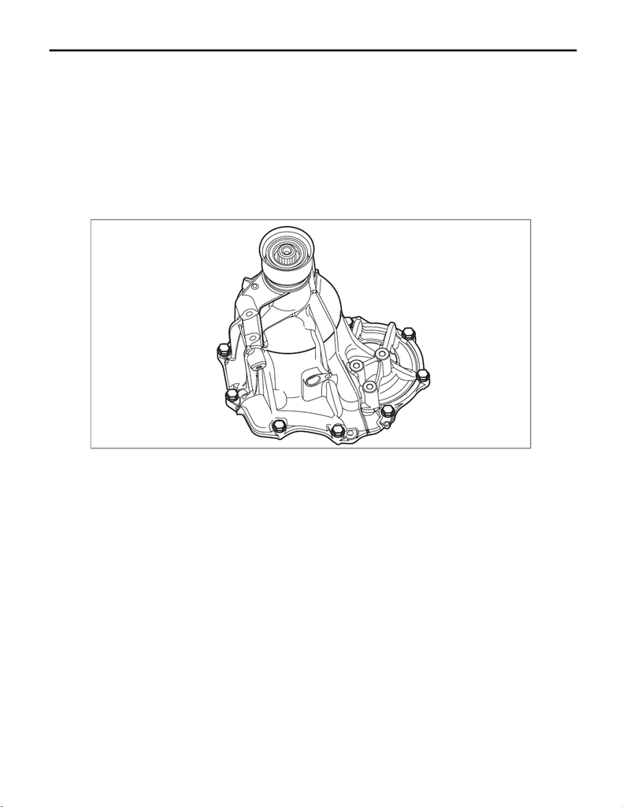

CVT(TR690)-142

Extension Case

CONTINUOUSLY VARIABLE TRANSMISSION

28.Extension Case

A: REMOVAL

1) Remove the transmission assembly from the vehicle. <Ref. to CVT(TR690)-56, REMOVAL, Automatic

Transmission Assembly.>

2) Remove the front wheel speed sensor. <Ref. to CVT(TR690)-105, REMOVAL, Front Wheel Speed Sen-

sor.>

3) Remove the rear wheel speed sensor. <Ref. to CVT(TR690)-107, REMOVAL, Rear Wheel Speed Sen-

sor.>

4) Remove the harness clip, and remove the extension case.

NOTE:

The total number of extension case mounting bolts is 10.

AT-07358

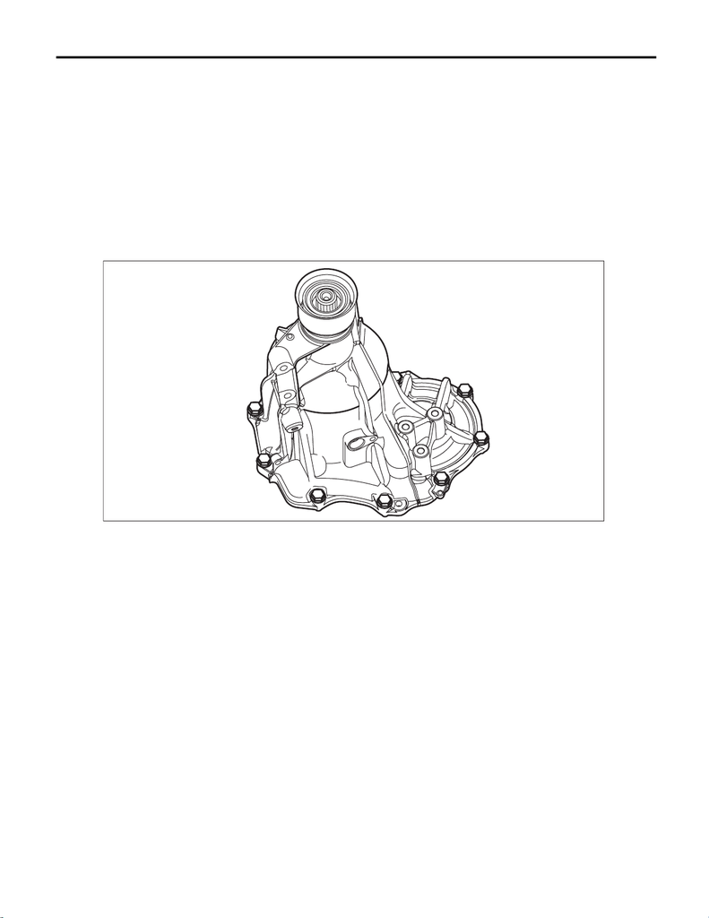

CVT(TR690)-143

Extension Case

CONTINUOUSLY VARIABLE TRANSMISSION

B: INSTALLATION

1) Clean the mating surface of the extension case and intermediate case.

2) Select the rear drive shaft shim. <Ref. to CVT(TR690)-149, ADJUSTMENT, Rear Drive Shaft.>

3) Select the shim for transfer reduction driven gear. <Ref. to CVT(TR690)-161, ADJUSTMENT, Transfer

Reduction Driven Gear.>

4) Install the selected rear drive shaft shims to the rear drive shaft.

5) Attach the selected shim to transfer reduction driven gear assembly.

6) Install the gasket and the extension case.

NOTE:

Use a new gasket.

Tightening torque:

25 N·m (2.5 kgf-m, 18.4 ft-lb)

7) Install the rear wheel speed sensor. <Ref. to CVT(TR690)-108, INSTALLATION, Rear Wheel Speed Sen-

sor.>

8) Install the front wheel speed sensor. <Ref. to CVT(TR690)-105, INSTALLATION, Front Wheel Speed

Sensor.>

9) Install the transmission assembly. <Ref. to CVT(TR690)-69, INSTALLATION, Automatic Transmission

Assembly.>

AT-07358

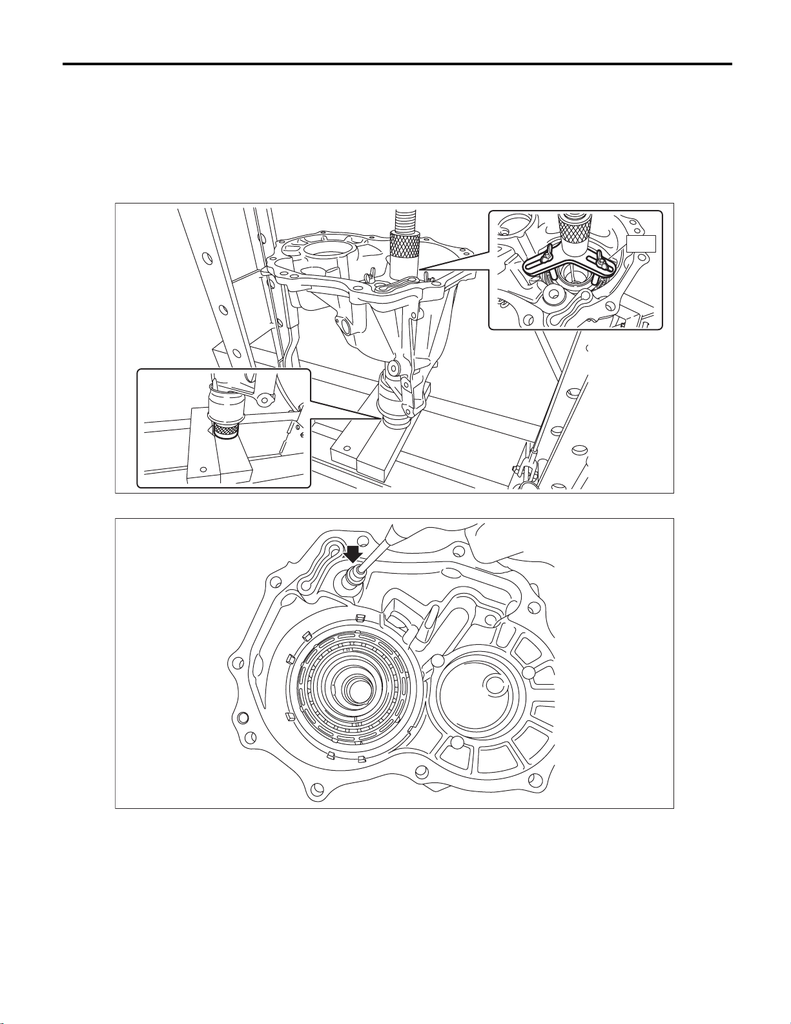

CVT(TR690)-144

Extension Case

CONTINUOUSLY VARIABLE TRANSMISSION

C: DISASSEMBLY

1) Remove the dust cover from extension case.

2) Remove the snap ring using the ST and press.

CAUTION:

If the operation is performed with the dust cover installed, place a table between the extension case

and the press table.

ST 18762AA001 COMPRESSOR SPECIAL TOOL

3) Supply compressed air to remove the transfer clutch piston.

4) Remove the D-ring and O-ring from the transfer clutch piston.

5) Remove the extension case oil seal from the extension case.

6) Remove the plug from the extension case.

AT-07391

ST

AT-07392

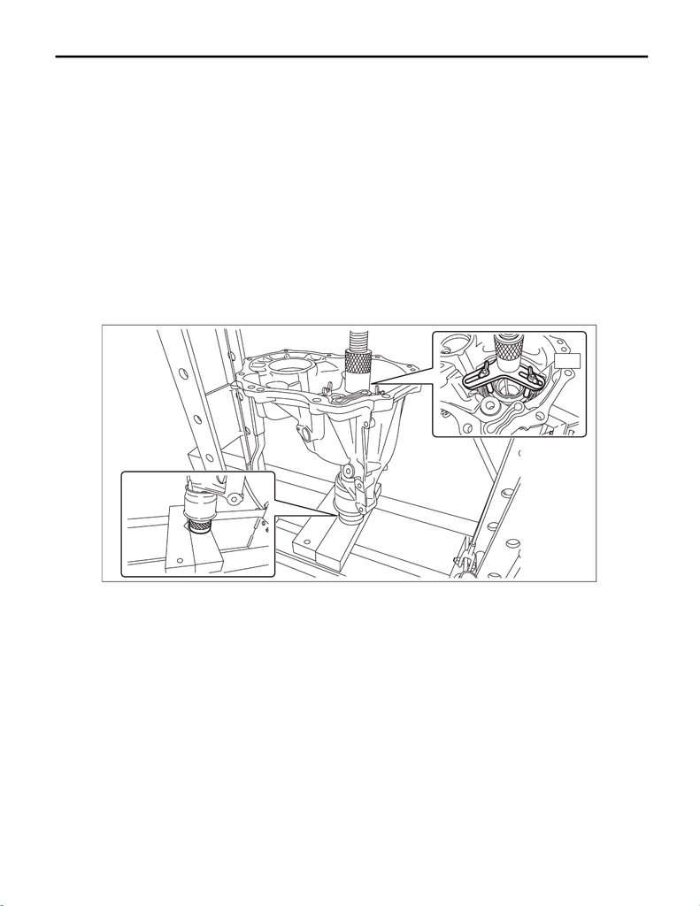

CVT(TR690)-145

Extension Case

CONTINUOUSLY VARIABLE TRANSMISSION

D: ASSEMBLY

1) Install the O-ring and plug.

NOTE:

Use new O-rings.

Tightening torque:

25 N·m (2.5 kgf-m, 18.4 ft-lb)

2) Install the D-ring and O-ring to the transfer clutch piston.

NOTE:

• Use new D-rings and O-rings.

• Apply CVTF to the D-rings and O-rings of the transfer clutch piston assembly.

3) Insert the transfer clutch piston, spring retainer, return spring and clutch spring retainer.

4) Using the ST and a press, install the snap ring.

CAUTION:

If the operation is performed with the dust cover installed, place a table between the extension case

and the press table.

ST 18762AA001 COMPRESSOR SPECIAL TOOL

5) Press-fit the dust cover into extension case.

6) Install the extension case oil seal to extension case.

ST 498057300 INSTALLER

E: INSPECTION

• Use compressed air to make sure the extension case routes are not clogged or leaking.

• Check the D-rings and O-rings for damage.

• Make sure the snap ring is not worn and the return spring has no permanent distortion, damage, or defor-

mation.

• Check the ball bearing for smooth rotation.

• Check the ball bearing for excessive looseness.

• Check there is no leak of CVTF from the joint between extension case and intermediate case.

• Check there is no damage or cracks on the extension case.

F: ADJUSTMENT

NOTE:

When replacing the extension case, select the rear drive shaft shim and transfer reduction driven gear shim.

<Ref. to CVT(TR690)-149, ADJUSTMENT, Rear Drive Shaft.> <Ref. to CVT(TR690)-161, ADJUSTMENT,

Transfer Reduction Driven Gear.>

AT-07391

ST